# Project Python Foundations: FoodHub Data Analysis

### **Question 8**: Which is the most popular cuisine on weekends? [1 mark]

```python
# Let's filter the data set to get the weekend orders
pop_weekend = df[df['day_of_the_week']=='Weekend']
#pop_weekend
pop_weekend.groupby(['cuisine_type'])['order_id'].count().sort_values(ascending=False)
```

```
cuisine_type
American          415
Japanese          335
Italian           207
Chinese           163
Mexican            53
Indian             49
Mediterranean      32
Middle Eastern     32
Thai               15
French             13
Korean             11
Southern           11
Spanish            11
Vietnamese          4
Name: order_id, dtype: int64
```

#### Observations:

- The most popular cuisine on weekend is American cuisine, which has 415 orders during the weekend.

### **Question 9**: What percentage of the orders cost more than 20 dollars? [2 marks]

```python
# Let's count the number of orders more than $20 and get the percentage of it
df_result = df[(df['cost_of_the_order']>20)].count()
print('There are ',df_result['cost_of_the_order'], 'orders cost more than $20')
Percentage = ((df_result['cost_of_the_order'])/len(df['cost_of_the_order']))*100
print('Cost more than $20 orders are about ', round(Percentage, ndigits=2), '% of the total orders', sep='')
```

```
There are  555 orders cost more than $20
Cost more than $20 orders are about 29.24% of the total orders
```

### **Question 10**: What is the mean order delivery time? [1 mark]

```python
print('The mean delivery time for an order is ', round(df['delivery_time'].mean(), ndigits=2), 'minutes')
```

```
The mean delivery time for an order is  24.16 minutes
```

### **Question 11:** The company has decided to give 20% discount vouchers to the top 3 most frequent customers. Find the IDs of these customers and the number of orders they placed. [1 mark]

```python
df.groupby(['customer_id'])['order_id'].count().sort_values(ascending=False).head(3)
```

```
customer_id
52832    13
47440    10
83287     9
Name: order_id, dtype: int64
```

#### Observations:

- The top 3 frequent customers are; customer ids 52832, 47440 and 83287 with number of orders 13, 10 and 9 respectively.

### Multivariate Analysis

```python
# Lets make some important variables using existing variables for future use.

df['avg_del_time_per_rest'] = df.groupby(['restaurant_name'])['delivery_time'].transform('mean')
df['avg_foodprep_time_per_rest'] = df.groupby(['restaurant_name'])['food_preparation_time'].transform('mean')
df['total_time_per_rest'] = df['food_preparation_time'] + df['delivery_time']
df['total_time_avg_per_rest'] = df.groupby(['restaurant_name'])['total_time_per_rest'].transform('mean')
df['avg_cost_per_rest'] = df.groupby(['restaurant_name'])['cost_of_the_order'].transform('mean')
df['order_count'] = df.groupby(['restaurant_name'])['order_id'].transform('count')

df.info()
```

[output not shown]

```python
#Lets filter the dataframe based on rating and create a new dataframe named df_rating

df_rating = df[df["rating"] != 'Not given']
print(df_rating['rating'].value_counts())
print(df_rating.shape)

#Lets convert the rating datatype to float
df_rating['rating'] = df_rating['rating'].astype(int)
print(df_rating.info())
w.filterwarnings('ignore');  # suppressed an SettingWithCopyWarning
```

[output not shown]

```python
# Lets create some new columns in df_rating for the future use

df_rating['rating_count_per_rest'] = df_rating.groupby(['restaurant_name'])['rating'].transform('count')
df_rating['rating_sum_per_rest'] = df_rating.groupby(['restaurant_name'])['rating'].transform('sum')
df_rating['avg_rating_per_rest'] = df_rating['rating_sum_per_rest']/df_rating['rating_count_per_rest']
df_rating.info()
w.filterwarnings('ignore');  # suppressed an SettingWithCopyWarning
```

[output not shown]

### **Question 12**: Perform a multivariate analysis to explore relationships between the important variables in the dataset. (It is a good idea to explore relations between numerical variables as well as relations between numerical and categorical variables) [10 marks]

**Observations on correlations between variables:**

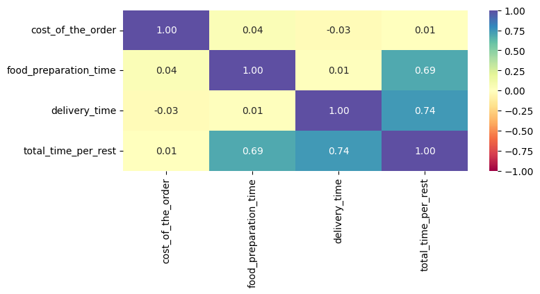

```python
# Let's see if there are any relationship exists between cost and time for the entire data set
df_select = df[['cost_of_the_order', 'food_preparation_time', 'delivery_time', 'total_time_per_rest']]
plt.figure(figsize=(8, 3))
sns.heatmap(df_select.corr(), annot=True, vmin=-1, vmax=1, fmt=".2f", cmap="Spectral")
plt.show()
```

**Observations:**

- It looks like cost of the order has no significant correlation with the food preparation time or delivery time.

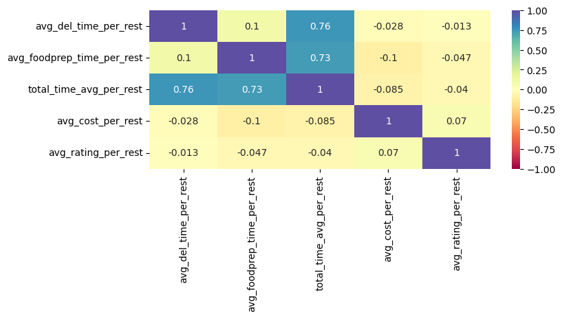

```python
# Let's see if there are any relationship exists between rating and other variables for the df_rating data frame
df_rating_select = df_rating[['avg_del_time_per_rest', 'avg_foodprep_time_per_rest',
       'total_time_avg_per_rest', 'avg_cost_per_rest', 'avg_rating_per_rest']]
plt.figure(figsize=(8,3))
sns.heatmap(df_rating_select.corr(),annot=True,cmap='Spectral',vmin=-1,vmax=1)
plt.show()
```

**Observations:**

- We would expect some correlation between food delivery time vs rating or cost vs rating. However heat map shows no significant correlations to the above variables to average ratings of the restaurants.

**Total time to delivery vs Restaurant affected by the day of the week:**

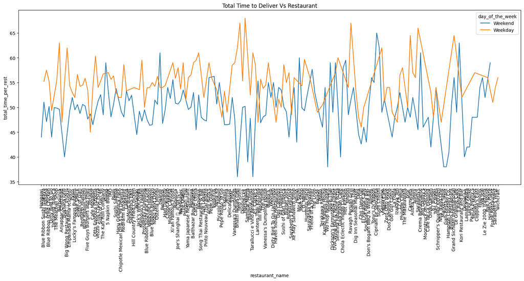

```python
plt.figure(figsize = (20,7))
plt.xticks(rotation=90)
sns.lineplot(data=df, x='restaurant_name', y='total_time_per_rest', hue='day_of_the_week', ci=False).set(title='Total Time to Deliver Vs Restaurant')
plt.show()
w.filterwarnings('ignore');  # suppressed an UserWarning
```

Observations:

**Average cost vs Restaurant**

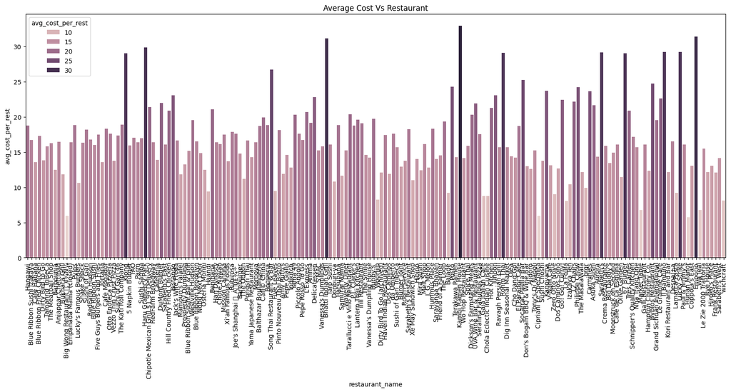

```python
plt.figure(figsize = (20,7))
plt.xticks(rotation=90)
sns.barplot(data=df, x='restaurant_name', y='avg_cost_per_rest', hue='avg_cost_per_rest').set(title='Average Cost Vs Restaurant')
w.filterwarnings('ignore');  # suppressed an UserWarning
```

```python
df['avg_cost_per_rest'].describe()
```

```
count    1898.000000
mean       16.498851
std         2.480705
min         5.720000
25%        15.887000
50%        16.344886
75%        17.315521
max        32.930000
Name: avg_cost_per_rest, dtype: float64
```

```python
df[df['avg_cost_per_rest']>25].count()
```

```
order_id                      16
customer_id                   16
restaurant_name               16
cuisine_type                  16
cost_of_the_order             16
day_of_the_week               16
rating                        16
food_preparation_time         16
delivery_time                 16
avg_del_time_per_rest         16
avg_foodprep_time_per_rest    16
total_time_per_rest           16
total_time_avg_per_rest       16
avg_cost_per_rest             16
order_count                   16
dtype: int64
```

**Observations:**

**Average Cost vs Order Count**

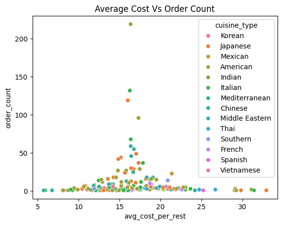

```python
sns.scatterplot(data=df, x='avg_cost_per_rest', y='order_count', hue='cuisine_type').set(title='Average Cost Vs Order Count');
```

**Observations:**

- It looks like between 15-18 dollars more orders are placed. When the cost is too cheap or expensive the number of orders are low.

**Average rating vs Restaurant**

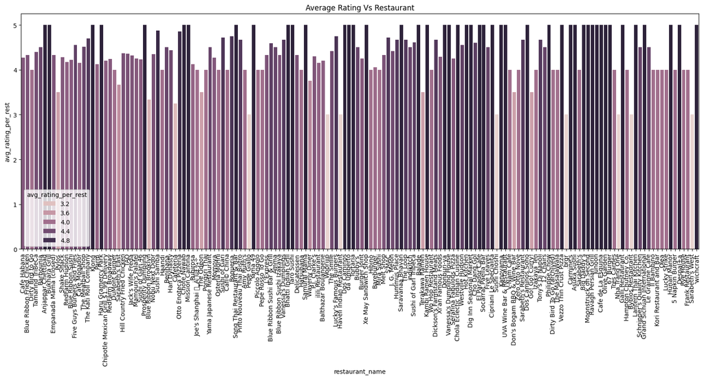

```python
plt.figure(figsize = (20,7))
plt.xticks(rotation=90)
sns.barplot(data=df_rating, x='restaurant_name', y='avg_rating_per_rest', hue='avg_rating_per_rest').set(title='Average Rating Vs Restaurant')
w.filterwarnings('ignore');  # suppressed an UserWarning
```

```python
df_filter = df_rating[(df_rating['avg_rating_per_rest']==5)]
df_filter['restaurant_name'].nunique()
```

```
47
```

```python
df_filter = df_rating[(df_rating['avg_rating_per_rest']>=4)]
df_filter['restaurant_name'].nunique()
```

```
139
```

**Observations:**

- There are 47 restaurants with average rating 5.
- And 139 restaurants have 4 or more average rating.

**Food Preparation Time Vs Cuisine type**

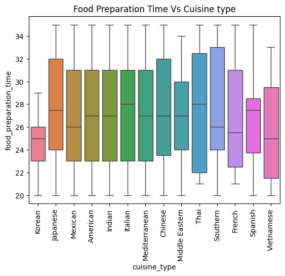

```python
sns.boxplot(data=df, x='cuisine_type', y='food_preparation_time', hue='cuisine_type', showfliers=False).set(title='Food Preparation Time Vs Cuisine type')
plt.xticks(rotation=90);
```

**Observations:**

- Median food preparation time is highest for the Italian and Thai restaurants.
- Median food preparation time is lowest for the Korean and Vietnamese restaurants.
- Range of food preparation time is lowest for the Korean restaurants.

**Cost of the order Vs Cuisine type**

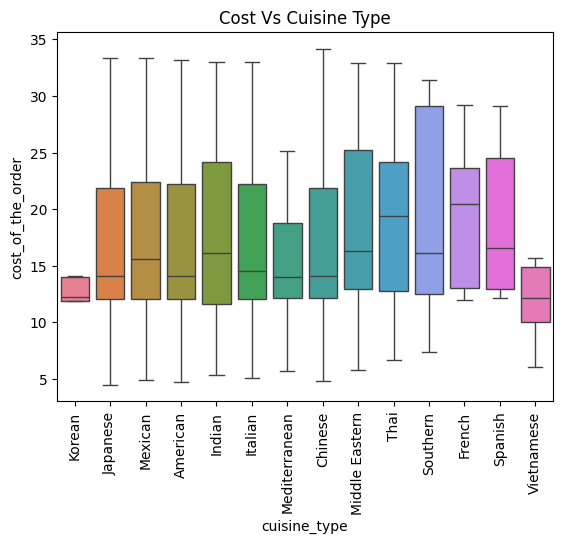

```python
sns.boxplot(data=df, x='cuisine_type', y='cost_of_the_order', hue='cuisine_type', showfliers=False).set(title='Cost Vs Cuisine Type')
plt.xticks(rotation=90);
```

**Observations:**

- Median cost is highest for the French restaurants and least for the Vietnamese restaurants.
- Cost range is lowest for the Korean restaurants.

**Delivery time, Food Preparation Time and Total Time vs Day of the week:**

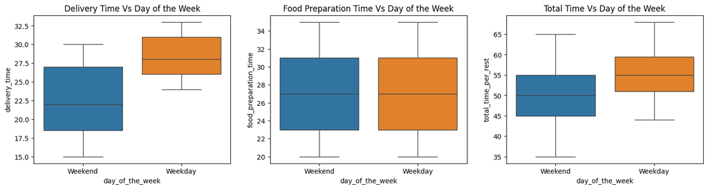

```python
Fig, axes = plt.subplots(1, 3, figsize=(18, 4))
sns.boxplot(ax=axes[0], data=df, x='day_of_the_week', y='delivery_time', hue='day_of_the_week').set(title='Delivery Time Vs Day of the Week')
sns.boxplot(ax=axes[1], data=df, x='day_of_the_week', y='food_preparation_time', hue='day_of_the_week').set(title='Food Preparation Time Vs Day of the Week')
sns.boxplot(ax=axes[2], data=df, x='day_of_the_week', y='total_time_per_rest', hue='day_of_the_week').set(title='Total Time Vs Day of the Week');
```

**Observations:**

- Median delivery time is high for the weekdays than for the weekends.
- Regardless of the day, median food preparation time is however do not change.
- Total time to food preparation and delivery is therefore again higher for the weekdays than the weekends.

**Average cost vs Day of the week on left and Average rating vs Day of the week on right**

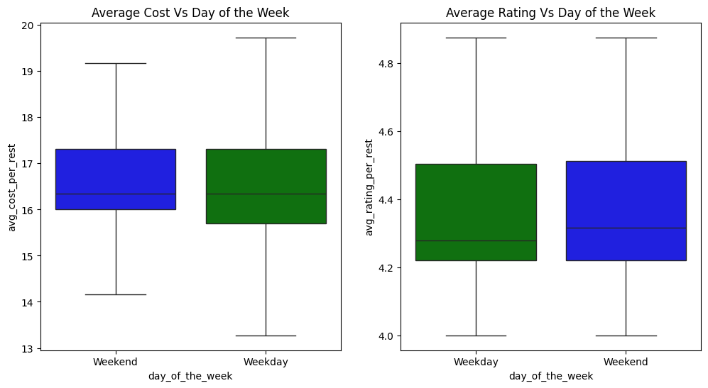

```python
Fig, axes = plt.subplots(1, 2, figsize=(12,6))
my_pal = {"Weekend": "b", "Weekday": "g"}
sns.boxplot(ax=axes[0], data=df, x='day_of_the_week', y='avg_cost_per_rest',  hue='day_of_the_week', palette=my_pal, showfliers=False).set(title='Average Cost Vs Day of the Week')
sns.boxplot(ax=axes[1], data=df_rating, x= 'day_of_the_week',  y='avg_rating_per_rest',hue='day_of_the_week', palette=my_pal, showfliers=False).set(title='Average Rating Vs Day of the Week');
```

**Observations:**

- Median of the average cost per restaurant is same for all days of the week.
- However range of the average cost is higher for the weekdays than for the weekend.
- Median of the average rating per restaurant is greater for the weekend than weekdays, this could be due to the number of orders on weekends is higher than weekdays.

**Average rating vs Aaverage cost on left and Average rating vs Total time average on right**

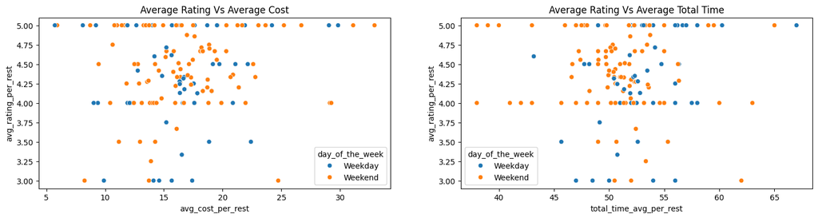

```python
Fig, axes = plt.subplots(1, 2, figsize=(18, 4))
sns.scatterplot(ax=axes[0], data=df_rating, x='avg_cost_per_rest', y='avg_rating_per_rest', hue='day_of_the_week').set(title='Average Rating Vs Average Cost')
sns.scatterplot(ax=axes[1], data=df_rating, x='total_time_avg_per_rest', y='avg_rating_per_rest', hue='day_of_the_week').set(title='Average Rating Vs Average Total Time');
```

**Observations:**

- The average rating shows no correlation to average food cost or the average of total time takes to deliver.
- Also it does not show any pattern with the day of the week.

**Average rating vs Average delivery time on left and Average rating vs Average food preparation time on right**

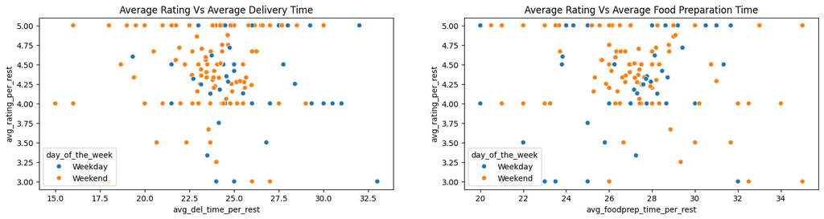

```python
Fig, axes = plt.subplots(1, 2, figsize=(18, 4))
sns.scatterplot(ax=axes[0], data=df_rating, x='avg_del_time_per_rest', y='avg_rating_per_rest', hue='day_of_the_week').set(title='Average Rating Vs Average Delivery Time')
sns.scatterplot(ax=axes[1], data=df_rating, x='avg_foodprep_time_per_rest', y='avg_rating_per_rest', hue='day_of_the_week').set(title='Average Rating Vs Average Food Preparation Time');
```

**Observations:**

- Average rating again shows no correlation to the average delivery time, average food preparation time or the day of the week.

### **Question 13:** The company wants to provide a promotional offer in the advertisement of the restaurants. The condition to get the offer is that the restaurants must have a rating count of more than 50 and the average rating should be greater than 4. Find the restaurants fulfilling the criteria to get the promotional offer. [3 marks]

```python
data = df_rating.loc[(df_rating['rating_count_per_rest'] >50) & (df_rating['avg_rating_per_rest'] >4)]
data = data[['restaurant_name', 'rating_count_per_rest', 'avg_rating_per_rest']]
data.drop_duplicates()
```

|  | restaurant_name | rating_count_per_rest | avg_rating_per_rest |
| --- | --- | --- | --- |
| 3 | Blue Ribbon Fried Chicken | 64 | 4.328125 |
| 15 | Shake Shack | 133 | 4.278195 |
| 19 | Blue Ribbon Sushi | 73 | 4.219178 |
| 26 | The Meatball Shop | 84 | 4.511905 |

**Observations:**

- There are 4 restaurants fullfilling the criteria to receive the promotional offer with more than 50 rating counts and average rating greater than 4.
- The winners are Shake Shack, The Meatball Shop, Blue Ribbon Sushi and Blue Ribbon Fried Chicken.

### **Question 14:** The company charges the restaurant 25% on the orders having cost greater than 20 dollars and 15% on the orders having cost greater than 5 dollars. Find the net revenue generated by the company across all orders. [3 marks]

```python
# Let's calculate the revenue using a for loop

charge25_list = []
charge15_list = []

for row in df.itertuples():
  if row.cost_of_the_order > 20:
    charge25 = row.cost_of_the_order * 0.25
    charge25_list.append(charge25)
  elif ((row.cost_of_the_order < 20) & (row.cost_of_the_order > 5)):
    charge15 = row.cost_of_the_order * 0.15
    charge15_list.append(charge15)
```

```python
charge_list = charge25_list + charge15_list
charge_df = pd.DataFrame(charge_list, columns=['charge'])
a = charge_df['charge'].sum()
print('The total revenue is $', round(a, 2), sep='')
```

```
The total revenue is $6166.3
```

```python
# Let's compute the revenue using function revenue
def revenue(x):
    if x > 20:
        return x*0.25
    elif x > 5:
        return x*0.15
    else:
        return x*0

df['Revenue'] = df['cost_of_the_order'].apply(revenue)
df.head()
```

|  | order_id | customer_id | restaurant_name | cuisine_type | cost_of_the_order | day_of_the_week | rating | food_preparation_time | delivery_time | avg_del_time_per_rest | avg_foodprep_time_per_rest | total_time_per_rest | total_time_avg_per_rest | avg_cost_per_rest | order_count | Revenue |
| --- | --- | --- | --- | --- | --- | --- | --- | --- | --- | --- | --- | --- | --- | --- | --- | --- |
| 0 | 1477147 | 337525 | Hangawi | Korean | 30.75 | Weekend | Not given | 25 | 20 | 21.000000 | 23.000000 | 45 | 44.000000 | 18.745000 | 2 | 7.6875 |
| 1 | 1477685 | 358141 | Blue Ribbon Sushi Izakaya | Japanese | 12.08 | Weekend | Not given | 25 | 23 | 23.482759 | 28.724138 | 48 | 52.206897 | 16.727241 | 29 | 1.8120 |
| 2 | 1477070 | 66393 | Cafe Habana | Mexican | 12.23 | Weekday | 5 | 23 | 28 | 25.562500 | 26.750000 | 51 | 52.312500 | 13.581875 | 16 | 1.8345 |
| 3 | 1477334 | 106968 | Blue Ribbon Fried Chicken | American | 29.20 | Weekend | 3 | 25 | 15 | 24.145833 | 27.197917 | 40 | 51.343750 | 17.315521 | 96 | 7.3000 |
| 4 | 1478249 | 76942 | Dirty Bird to Go | American | 11.59 | Weekday | 4 | 25 | 24 | 24.750000 | 23.250000 | 49 | 48.000000 | 13.812500 | 4 | 1.7385 |

```python
# Let's calculate the total revenue
total_rev = df['Revenue'].sum()
print('The total revenue is $', round(total_rev, 2), sep='')
```

```
The total revenue is $6166.3
```

```python
df.groupby(['restaurant_name','order_count', 'cuisine_type'])['Revenue'].sum().sort_values(ascending=False)
```

```
restaurant_name             order_count  cuisine_type
Shake Shack                 219          American        703.6070
Blue Ribbon Sushi           119          Japanese        360.4605
The Meatball Shop           132          Italian         356.2745
Blue Ribbon Fried Chicken   96           American        340.2035
Parm                        68           Italian         218.5570
                                                           ...
Market Table                1            American          1.0185
Wa Jeal                     1            Chinese           1.0110
Cipriani Le Specialita      1            Italian           0.8880
Big Wong Restaurant _¤¾Ñ¼  1            Chinese           0.8880
Hunan Manor                 1            Chinese           0.8580
Name: Revenue, Length: 179, dtype: float64
```

**Observations:**

The company total revenue from the orders is 6166.30 dollars.

### **Question 15:** The company wants to analyze the total time required to deliver the food. What percentage of orders take more than 60 minutes to get delivered from the time the order is placed? (The food has to be prepared and then delivered.) [2 marks]

```python
df_time = df.loc[(df['total_time'] > 60)].count()
percent_orders = (df_time['total_time']/len(df['total_time']))*100
round(percent_orders, ndigits=2)
```

```
10.54
```

**Observations:**

- About 10.5 percent of orders take more than 60 minutes to deliver.

### **Question 16:** The company wants to analyze the delivery time of the orders on weekdays and weekends. How does the mean delivery time vary during weekdays and weekends? [2 marks]

```python
df.groupby(['day_of_the_week'])['delivery_time'].mean()
```

```
day_of_the_week
Weekday    28.340037
Weekend    22.470022
Name: delivery_time, dtype: float64
```

**Observations:**

- The mean delivery time for the weekdays are higher than the weekends.
- During the week it is about 28 minutes and in the weekends it is only about 22 minutes.

### Conclusion and Recommendations

### **Question 17:** What are your conclusions from the analysis? What recommendations would you like to share to help improve the business? (You can use cuisine type and feedback ratings to drive your business recommendations.) [6 marks]

### Conclusions:

1. 50% of the orders took about 23-33 minutes to prepare, with an average of 27 minutes. The median food preparation time is highest for Italian and Thai restaurants and lowest for Korean and Vietnamese restaurants.
2. 50% of orders are delivered within 20-28 minutes, with an average of 24 minutes. Delivery time is higher on weekdays than on weekends. During the week, it is about 28 minutes, and on weekends, it is only about 22 minutes. About 10.5 percent of orders take more than 60 minutes to deliver. We have to dig into more details about this 10.5% of the orders and find out what causes this.
3. The rating has no correlation to food delivery time, average food preparation time, cost of the order, or day of the week. 38.8% of orders are not rated. The median of the average rating is greater on the weekend than on weekdays. There are 47 restaurants with an average rating of 5, while there are 4 restaurants with a rating count of greater than 50 and an average rating of greater than 4.
4. The order cost has no significant correlation with the food preparation or delivery time. 50% of the orders cost between 12-23 dollars, with an average of 16.5 dollars. There are 555 orders, which is about 29 % of the total orders that cost more than $20. Orders are highest for the intermediate costs, neither for the expensive nor for the cheap. The median cost is highest for French restaurants and lowest for Vietnamese restaurants. The median of the average cost is the same for all days of the week. However, the average cost range is higher for weekdays than for weekends.
5. Out of 178 restaurants, Shake Shack, The Meatball Shop, Blue Ribbon Sushi, Blue Ribbon Fried Chicken, and Parm are the top five based on order counts.
6. Out of 14 cuisine types, American cuisine is the most favorite, it is also the most popular cuisine of the weekend. The next favorites are Japanese, Italian, and Chinese. Vietnamese cuisine has the lowest preference.
7. Number of food orders are high for the weekends than the weekdays.
8. Some customers are frequent customers.
9. The company can earn total revenue of 6166.30 dollars by charging 25% from orders cost >20 dollars and 15% from orders cost >5 dollars.